# Projekt 2 - kamień milowy 1

*Niewiasty WRS - Martyna Majchrzak, Agata Makarewicz, Renata Rólkiewicz*

## Wczytanie pakietów

```python
import pandas as pd
import numpy as np
import sklearn
import seaborn as sns
import matplotlib.pyplot as plt
import warnings
warnings.filterwarnings('ignore')
```

## Zbiór danych

Każdy wiersz w zbiorze opisuję sesję innego użytkownika podczas zakupów internetowych. Dane zostały zebrane na przestrzeni jednego roku, aby uniknąć wpływów czynników takich jak kampanie reklamowe, specjalne oferty, profil użytkownika, pora roku itd. Odwiedzone podczas dokonywania zakupu witryny zostały podzielone na 3 typy: Administrative - administracyjne, Informational - informacyjne oraz ProductRelated - związane z produktem.

https://archive.ics.uci.edu/ml/datasets/Online+Shoppers+Purchasing+Intention+Dataset

**Zmienne związana z typami witryn:**

- Administrative - liczba odwiedzonych stron typu "Administrative" (zarządzanie kontem)
- Administrative_Duration - sumaryczny czas (w sekundach) spędzony na stronach typu "Administrative"
- Informational - liczba odwiedzonych stron typu "Informational" (informacje o stronie, kontakt, adres)
- Informational_Duration - sumaryczny czas (w sekundach) spędzony na stronach typu "Informational"
- ProductRelated - liczba odwiedzonych stron typu "ProductRelated" (strony związane z produktami)
- ProductRelated_Duration - sumaryczny czas (w sekundach) spędzony na stronach typu "ProductRelated"

**Zmienne związane z analizą Google Analytics:**

- BounceRates - miara "BounceRate" dla danej strony oznacza procent sesji które zaczęły się od niej, w których bezpośrednio po niej nastąpiło opuszczenie witryny
- ExitRates - miara "ExitRate" dla danej strony oznacza procent sesji które ją zawierały, w których bezpośrednio po niej nastąpiło opuszczenie witryny
- PageValues - średnia wartość stron odwiedzonych przed dokonaniem transakcji

**Informacje o użytkowniku:**

- VisitorType - typ użytkownika (Returning_Visitor/New_Visitor/Other)
- OperatingSystems - system operacyjny użytkownika (zakodowane numerycznie liczbami od 1 do 8)
- Browser - przeglądarka użytkownika (zakodowane numerycznie liczbami od 1 do 13)
- Region - region, z którego pochodzi użytkownik (zakodowane numerycznie liczbami od 1 do 9)
- TrafficType - określa, w jaki sposób użytkownik dostał się na stronę, np. wpisując hasło w wyszukiwarkę/ klikając link (zakodowane numerycznie liczbami od 1 do 20)

**Informacje o transakcji:**

- SpecialDay - bliskość daty transakcji do szczególnych dni lub świąt (np. Dzień Matki) z uwzględnieniem np. czasu dostawy. Przykład: dla Walentynek - wartości niezerowe są od 2 do 12 lutego, a najwyższą wartość (równą 1) przyjmuje 8 lutego
- Month - miesiąc
- Weekend - informacja czy zakup został dokonany w trakcie weekendu (False/True)
- Revenue - informacja czy doszło do transakcji (False/True)

Opisy miar Google Analytics https://support.google.com/analytics/answer/2525491?hl=en&ref_topic=6156780

```python
# wczytanie danych
data = pd.read_csv('online_shoppers_intention.csv')
data.head(10)
```

|  | Administrative | Administrative_Duration | Informational | Informational_Duration | ProductRelated | ProductRelated_Duration | BounceRates | ExitRates | PageValues | SpecialDay | Month | OperatingSystems | Browser | Region | TrafficType | VisitorType | Weekend | Revenue |
| --- | --- | --- | --- | --- | --- | --- | --- | --- | --- | --- | --- | --- | --- | --- | --- | --- | --- | --- |
| 0 | 0 | 0.0 | 0 | 0.0 | 1 | 0.000000 | 0.200000 | 0.200000 | 0.0 | 0.0 | Feb | 1 | 1 | 1 | 1 | Returning_Visitor | False | False |
| 1 | 0 | 0.0 | 0 | 0.0 | 2 | 64.000000 | 0.000000 | 0.100000 | 0.0 | 0.0 | Feb | 2 | 2 | 1 | 2 | Returning_Visitor | False | False |
| 2 | 0 | 0.0 | 0 | 0.0 | 1 | 0.000000 | 0.200000 | 0.200000 | 0.0 | 0.0 | Feb | 4 | 1 | 9 | 3 | Returning_Visitor | False | False |
| 3 | 0 | 0.0 | 0 | 0.0 | 2 | 2.666667 | 0.050000 | 0.140000 | 0.0 | 0.0 | Feb | 3 | 2 | 2 | 4 | Returning_Visitor | False | False |
| 4 | 0 | 0.0 | 0 | 0.0 | 10 | 627.500000 | 0.020000 | 0.050000 | 0.0 | 0.0 | Feb | 3 | 3 | 1 | 4 | Returning_Visitor | True | False |
| 5 | 0 | 0.0 | 0 | 0.0 | 19 | 154.216667 | 0.015789 | 0.024561 | 0.0 | 0.0 | Feb | 2 | 2 | 1 | 3 | Returning_Visitor | False | False |
| 6 | 0 | 0.0 | 0 | 0.0 | 1 | 0.000000 | 0.200000 | 0.200000 | 0.0 | 0.4 | Feb | 2 | 4 | 3 | 3 | Returning_Visitor | False | False |
| 7 | 1 | 0.0 | 0 | 0.0 | 0 | 0.000000 | 0.200000 | 0.200000 | 0.0 | 0.0 | Feb | 1 | 2 | 1 | 5 | Returning_Visitor | True | False |
| 8 | 0 | 0.0 | 0 | 0.0 | 2 | 37.000000 | 0.000000 | 0.100000 | 0.0 | 0.8 | Feb | 2 | 2 | 2 | 3 | Returning_Visitor | False | False |
| 9 | 0 | 0.0 | 0 | 0.0 | 3 | 738.000000 | 0.000000 | 0.022222 | 0.0 | 0.4 | Feb | 2 | 4 | 1 | 2 | Returning_Visitor | False | False |

**Struktura zbioru:**

```python
# Zamiana zmiennych kategorycznych na odpowiedni typ
data['Weekend'] = data['Weekend'].astype('object')
data['Revenue'] = data['Revenue'].astype('object')
data['OperatingSystems'] = data['OperatingSystems'].astype('object')
data['Browser'] = data['Browser'].astype('object')
data['Region'] = data['Region'].astype('object')
data['TrafficType'] = data['TrafficType'].astype('object')
# SpecialDay
```

```python
data.info()
```

```
<class 'pandas.core.frame.DataFrame'>
RangeIndex: 12330 entries, 0 to 12329
Data columns (total 18 columns):
Administrative             12330 non-null int64
Administrative_Duration    12330 non-null float64
Informational              12330 non-null int64
Informational_Duration     12330 non-null float64
ProductRelated             12330 non-null int64
ProductRelated_Duration    12330 non-null float64
BounceRates                12330 non-null float64
ExitRates                  12330 non-null float64
PageValues                 12330 non-null float64
SpecialDay                 12330 non-null float64
Month                      12330 non-null object
OperatingSystems           12330 non-null object
Browser                    12330 non-null object
Region                     12330 non-null object
TrafficType                12330 non-null object
VisitorType                12330 non-null object
Weekend                    12330 non-null object
Revenue                    12330 non-null object
dtypes: float64(7), int64(3), object(8)
memory usage: 1.7+ MB
```

Zbiór danych składa się z:

- 10 zmiennych numerycznych
- 8 kategorycznych

**Podsumowanie zmiennych:**

```python
data.describe()
```

|  | Administrative | Administrative_Duration | Informational | Informational_Duration | ProductRelated | ProductRelated_Duration | BounceRates | ExitRates | PageValues | SpecialDay |
| --- | --- | --- | --- | --- | --- | --- | --- | --- | --- | --- |
| count | 12330.000000 | 12330.000000 | 12330.000000 | 12330.000000 | 12330.000000 | 12330.000000 | 12330.000000 | 12330.000000 | 12330.000000 | 12330.000000 |
| mean | 2.315166 | 80.818611 | 0.503569 | 34.472398 | 31.731468 | 1194.746220 | 0.022191 | 0.043073 | 5.889258 | 0.061427 |
| std | 3.321784 | 176.779107 | 1.270156 | 140.749294 | 44.475503 | 1913.669288 | 0.048488 | 0.048597 | 18.568437 | 0.198917 |
| min | 0.000000 | 0.000000 | 0.000000 | 0.000000 | 0.000000 | 0.000000 | 0.000000 | 0.000000 | 0.000000 | 0.000000 |
| 25% | 0.000000 | 0.000000 | 0.000000 | 0.000000 | 7.000000 | 184.137500 | 0.000000 | 0.014286 | 0.000000 | 0.000000 |
| 50% | 1.000000 | 7.500000 | 0.000000 | 0.000000 | 18.000000 | 598.936905 | 0.003112 | 0.025156 | 0.000000 | 0.000000 |
| 75% | 4.000000 | 93.256250 | 0.000000 | 0.000000 | 38.000000 | 1464.157213 | 0.016813 | 0.050000 | 0.000000 | 0.000000 |
| max | 27.000000 | 3398.750000 | 24.000000 | 2549.375000 | 705.000000 | 63973.522230 | 0.200000 | 0.200000 | 361.763742 | 1.000000 |

**Czy są jakieś brakujące wartości?**

```python
data.isnull().sum()
```

```
Administrative             0
Administrative_Duration    0
Informational              0
Informational_Duration     0
ProductRelated             0
ProductRelated_Duration    0
BounceRates                0
ExitRates                  0
PageValues                 0
SpecialDay                 0
Month                      0
OperatingSystems           0
Browser                    0
Region                     0
TrafficType                0
VisitorType                0
Weekend                    0
Revenue                    0
dtype: int64
```

**Duplikaty:**

```python
data.duplicated().value_counts()
```

```
False    12205
True       125
dtype: int64
```

W naszym zbiorze występują duplikaty. Jest to 125 wierszy, dla których:

- Administrative oraz Informational równe jest 0, a więc dotyczą one sesji, gdzie klient wyświetlił tylko jedną (dla 7 przypadków - dwie) stronę z kategorii ProductRelated
- ProductRelated_Duration - zawsze równe 0, a więc klient praktycznie od razu wyszedł ze strony
- typ klienta - zawsze Returning_Visitor
- nie doszło do transakcji (Revenue == False)
- TrafficType w głownej mierze wynosi 1 lub 3

```python
data[data.duplicated()].head()
#data=data.drop_duplicates()
#data[data.duplicated()].TrafficType.value_counts()
```

|  | Administrative | Administrative_Duration | Informational | Informational_Duration | ProductRelated | ProductRelated_Duration | BounceRates | ExitRates | PageValues | SpecialDay | Month | OperatingSystems | Browser | Region | TrafficType | VisitorType | Weekend | Revenue |
| --- | --- | --- | --- | --- | --- | --- | --- | --- | --- | --- | --- | --- | --- | --- | --- | --- | --- | --- |
| 158 | 0 | 0.0 | 0 | 0.0 | 1 | 0.0 | 0.2 | 0.2 | 0.0 | 0.0 | Feb | 1 | 1 | 1 | 3 | Returning_Visitor | False | False |
| 159 | 0 | 0.0 | 0 | 0.0 | 1 | 0.0 | 0.2 | 0.2 | 0.0 | 0.0 | Feb | 3 | 2 | 3 | 3 | Returning_Visitor | False | False |
| 178 | 0 | 0.0 | 0 | 0.0 | 1 | 0.0 | 0.2 | 0.2 | 0.0 | 0.0 | Feb | 3 | 2 | 3 | 3 | Returning_Visitor | False | False |
| 418 | 0 | 0.0 | 0 | 0.0 | 1 | 0.0 | 0.2 | 0.2 | 0.0 | 0.0 | Mar | 1 | 1 | 1 | 1 | Returning_Visitor | True | False |
| 456 | 0 | 0.0 | 0 | 0.0 | 1 | 0.0 | 0.2 | 0.2 | 0.0 | 0.0 | Mar | 2 | 2 | 4 | 1 | Returning_Visitor | False | False |

## Rozkłady zmiennych związanych z witrynami

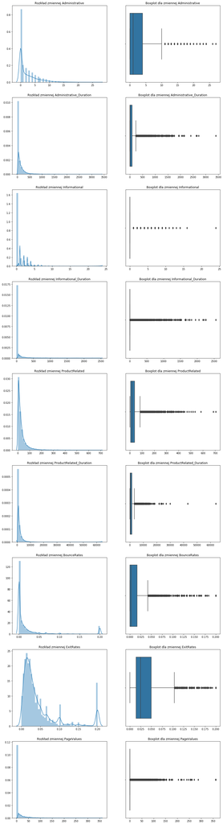

```python
var=list(data.columns[0:9])
fig, axes=plt.subplots(9, 2, figsize=(15, 60))
for i in range(0, len(var)):
    sns.distplot(data[var[i]], ax=axes[i, 0]).set(xlabel="", title='Rozkład zmiennej '+var[i])
    sns.boxplot(data[var[i]], ax=axes[i, 1]).set(xlabel='', title='Boxplot dla zmiennej '+var[i])
```

## Rozkłady zmiennych kategorycznych

### Revenue

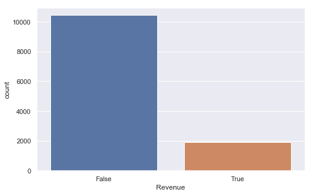

```python
sns.set(style="darkgrid")
plt.figure(figsize=(8,5))
sns.countplot(data.Revenue)
#data.Revenue.value_counts()
```

Obserwacje, dla których transakcja się odbyła stanowią mniejszość (15,5% wszystkich obserwacji).

### OperatingSystems, Browser, Region, TrafficType

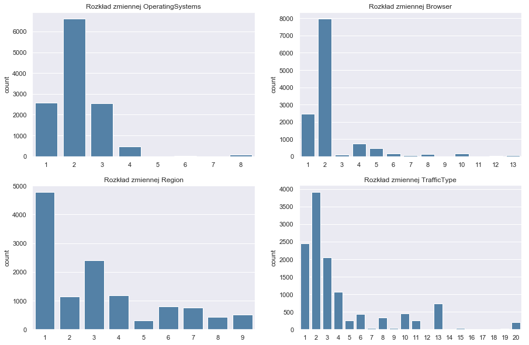

```python
var2=['OperatingSystems','Browser','Region','TrafficType']
fig, axes=plt.subplots(2, 2, figsize=(15, 10))
for i in range(0, len(var2)):
    sns.countplot(data[var2[i]], ax=axes[i//2, i%2], color='steelblue').set(xlabel="", title='Rozkład zmiennej '+var2[i])
```

- OperatingSystem: najwięcej obserwacji dla typów: 2,1,3
- Browser: zdecydowana przewaga 2, druga w kolejności - 1
- Region: najwięcej użytkowników z regionu 1 oraz 3
- TrafficType: najwięcej obserwacji dla 2,1,3

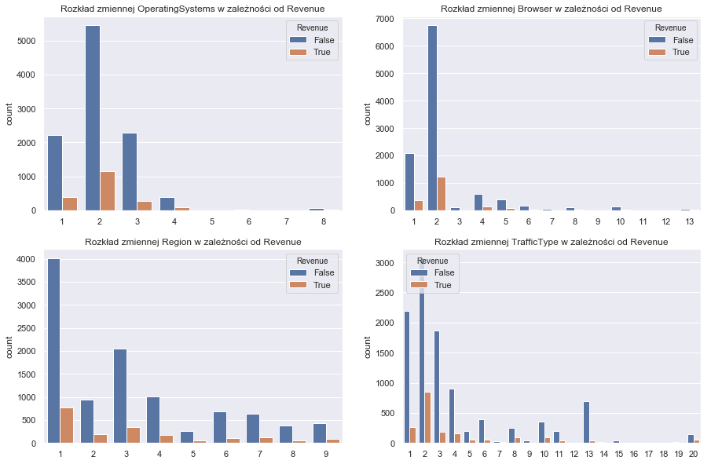

```python
fig, axes=plt.subplots(2, 2, figsize=(15, 10))
for i in range(0, len(var2)):
    sns.countplot(data[var2[i]], ax=axes[i//2, i%2], hue=data.Revenue).set(xlabel="", title='Rozkład zmiennej '+var2[i]+' w zależności od Revenue')
```

### Month

```
[Text(0.5, 0, ''), Text(0.5, 1.0, 'Rozkład zmiennej Month')]
```

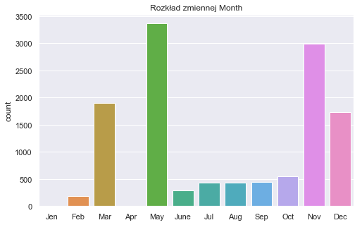

```python
plt.figure(figsize=(8,5))
sns.countplot(data.Month, order=['Jen','Feb','Mar','Apr','May','June','Jul','Aug','Sep','Oct','Nov','Dec']).set(xlabel="", title='Rozkład zmiennej Month')
```

- Zbiór nie zawiera żadnych rekordów dla stycznia oraz kwietnia
- Dominują zdecydowanie: maj, listopad, marzec oraz grudzień

Dotyczy to jednak wszystkich wizyt - zarówno tych, które skończyły się zakupem jak i nie. W podanych czterech miesiącach najczęściej uzytkownicy odwiedzali stronę. Sprawdźmy zatem w jakich miesiącach ich odwiedziny najczęściej kończyły się transakcją.

```
[Text(0.5, 0, ''),
```

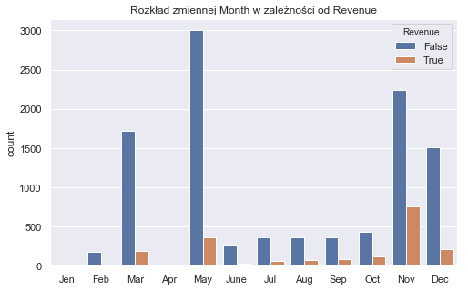

```python
plt.figure(figsize=(8,5))
sns.countplot(data.Month, order=['Jen','Feb','Mar','Apr','May','June','Jul','Aug','Sep','Oct','Nov','Dec'],
              hue=data.Revenue).set(xlabel="", title='Rozkład zmiennej Month w zależności od Revenue')
```

- Najczęściej zakupy dochodziły do finalizacji w listopadzie
- W maju jest widoczne zaintersowanie uzytkowników (liczba odwiedzających stronę), jednak na zakup decyduje się niewielka część z nich

```
[Text(0.5, 0, ''), Text(0.5, 1.0, 'Rozkład SpecialDay dla lutego i maja')]
```

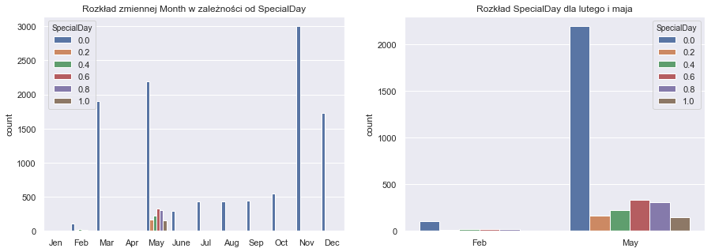

```python
fig, axes=plt.subplots(1, 2, figsize=(15, 5))
sns.countplot(data.Month, order=['Jen','Feb','Mar','Apr','May','June','Jul','Aug','Sep','Oct','Nov','Dec'],
              hue=data.SpecialDay, ax=axes[0]).set(xlabel="", title='Rozkład zmiennej Month w zależności od SpecialDay')
sns.countplot(data[data.Month=='Feb'].append(data[data.Month=='May']).Month, hue=data.SpecialDay,
              ax=axes[1]).set(xlabel="", title='Rozkład SpecialDay dla lutego i maja')
```

```python
#pd.unique((data[(data['SpecialDay']>0)]).Month)
(data[data['SpecialDay']>0]).Month.value_counts()
```

```
May    1172
Feb      79
Name: Month, dtype: int64
```

- Zaskakująco jedynie w lutym i maju obserwujemy jakiekolwiek zakupy związane ze zbliżającymi się świętami lub inną 'specjalną okazją'
- Zdecydowanie większość tych obserwacji przypada na maj

### Weekend

```
Proporcja dni weekendowych do roboczych:0.30310716550412176
```

```
[[Text(0, 0, 'Dni robocze'), Text(0, 0, 'Weekend')],
```

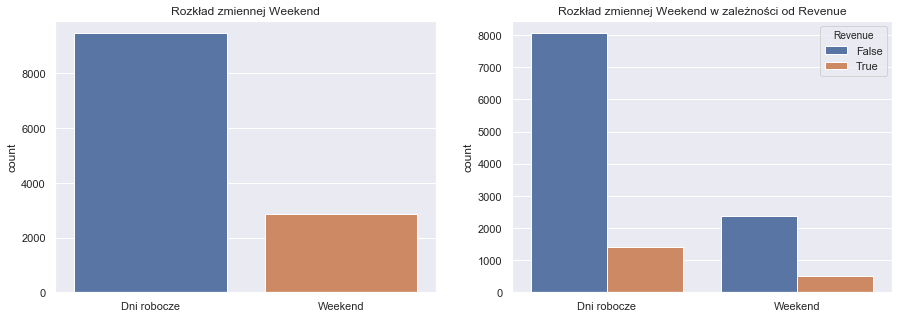

```python
fig, axes=plt.subplots(1, 2, figsize=(15, 5))
print('Proporcja dni weekendowych do roboczych:'+str(data.Weekend.value_counts()[1]/data.Weekend.value_counts()[0]))
sns.countplot(data.Weekend, ax=axes[0]).set(xlabel="", title='Rozkład zmiennej Weekend',
                                           xticklabels=['Dni robocze', 'Weekend'])
sns.countplot(data.Weekend, hue=data.Revenue,
              ax=axes[1]).set(xlabel="", title='Rozkład zmiennej Weekend w zależności od Revenue',
                             xticklabels=['Dni robocze', 'Weekend'])
```

Zaskakująco w weekendy użytkownicy rzadziej odwiedzają stronę (proporcja 0.3, normalnie 0.4)

### VisitorType

```
Returning_Visitor    10551
New_Visitor           1694
Other                   85
Name: VisitorType, dtype: int64
```

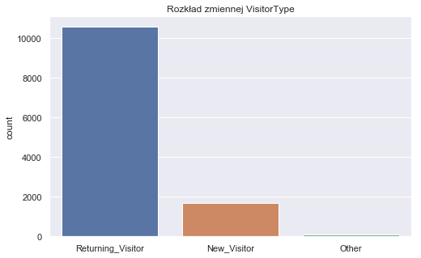

```python
plt.figure(figsize=(8,5))
sns.countplot(data.VisitorType).set(xlabel="", title='Rozkład zmiennej VisitorType')
data.VisitorType.value_counts()
```

Wyróżniamy trzy typy użytkowników:

- Returning_Visitor - powracający/stały klient
- New_Visitor - nowy klient
- Other - w opisie zbioru była informacja o dwóch, wspomnianych wyżej typach, nie wiadomo jak interpretować tę grupę. W dalszej części prac najprawdopodobniej zostaine ona usunięta

```
[Text(0.5, 0, ''),
```

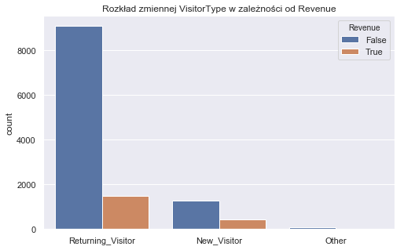

```python
plt.figure(figsize=(8,5))
sns.countplot(data.VisitorType, hue=data.Revenue).set(xlabel="", title='Rozkład zmiennej VisitorType w zależności od Revenue')
```

Nowi klienci są bardziej chętni do kupowania niż stali/powracający klienci.

## Korelacje zmiennych

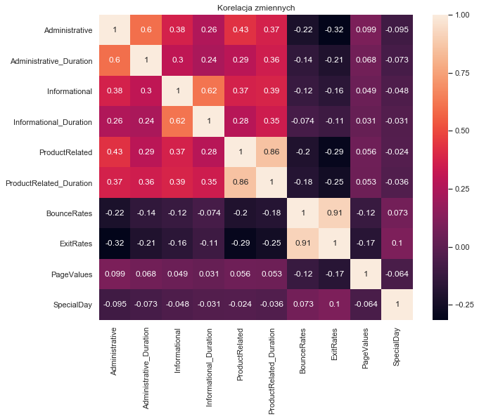

```python
Bouncecorr=data.corr()
plt.figure(figsize=(10,8))
sns.heatmap(Bouncecorr,
            xticklabels=Bouncecorr.columns,
            yticklabels=Bouncecorr.columns, annot=True).set_title("Korelacja zmiennych")
```